# Матрицы

Sofi Tormasheva

04 03 2017

Загружаем базу

```r
library(readr)
SpeedDating <- read_csv("~/pr3/project1/SpeedDating.csv")
```

Матрица для поиска похожих

```r
library(dplyr)
SD1 = select(SpeedDating, iid, age, gender, career_c, sports, tvsports, exercise, dining, museums, art, hiking, gaming, clubbing, reading, tv, theater, movies, concerts, music, shopping, yoga, attr3_1, sinc3_1, intel3_1, fun3_1, amb3_1, mn_sat)
```

Оставляем уникальных людей

```r
SD1un = unique(SD1)
SD1NA = na.omit(SD1un) #199
```

Предложение - исключить параметр mn_sat из-за малого количества данных

```r
SD2 = select(SpeedDating, iid, age, gender, career_c, sports, tvsports, exercise, dining, museums, art, hiking, gaming, clubbing, reading, tv, theater, movies, concerts, music, shopping, yoga, attr3_1, sinc3_1, intel3_1, fun3_1, amb3_1)
```

```r
SD2un = unique(SD2)
SD2NA = na.omit(SD2un)#535
#SD2NA1 = sapply(SD2NA, as.numeric)
#SD2NA1 = as.data.frame(SD2NA1)
```

535 уникальных человека в базе

База с расширенными личными характеристиками

```r
SD22 = select(SpeedDating, iid, age, field_cd, race, imprace, imprelig, goal, date, go_out, career_c, sports, tvsports, exercise, dining, museums, art, hiking, gaming, clubbing, reading, tv, theater, movies, concerts, music, shopping, yoga, exphappy, attr3_1, sinc3_1, intel3_1, fun3_1, amb3_1 )
```

```r
SD22un = unique(SD22)
SD22NA = na.omit(SD22un)#466
```

Матрица решений dec бинарность

```r
SDFdec = select (SpeedDating, iid, pid, dec)
SDFdec = na.omit(SDFdec) #8368
SDFdec$dec=as.numeric(SDFdec$dec)
```

Матрица решений like шкала 0-10

```r
SDFlike = select (SpeedDating, iid, pid, like)
SDFlike = na.omit(SDFlike) #8128
SDFlike$like = as.numeric(SDFlike$like)
```

Фильтрация матриц выбора партнеров

```r
SDFlike7= filter(SDFlike, like>7) #1885
```

```r
SDFdec1 = filter(SDFdec, dec>0) #3515
```

Вводим данные

```r
m= 0
n= 22
#c= 2
#SD2NANA <- filter(SD2NA, gender == m & age == seq(from = n-5, to = n+5, by = 1)& career_c == c)
SD2NANA1 = filter(SD2NA, gender == m , age >= n-3,  age <= n+3)
#seq(from = n-5, to = n+5, by = 1))
```

**Вот норм. решение этой проблемы:**

```r
SD2NANA2 = select(SD2NANA1, -age, -gender, -career_c)
SD2NANA2 <- as.data.frame(SD2NANA2)
rownames(SD2NANA2) = SD2NANA2$iid # дублирую iid в порядковый столбец (который не используется при расчетах)
SD2NANA2_0 = select(SD2NANA2, -iid)
new <- tail(SD2NANA2_0, n=1) # достаю одну последнюю строчку
new <- as.matrix(new)
big <- as.matrix(SD2NANA2_0) %>%
  t() # транспонирую матрицу big
new <-t(new)[,1] #  транспонирую матрицу new --> получаю из строчки вектор
new1 <-as.data.frame(new)
big <-t(abs(big-new))
big <- as.data.frame(big)
big$sum<-rowSums(big)
big$iid = SD2NANA2$iid
```

```r
antitop = head (arrange(big, sum), 10)
antitop$iid
```

```
##  [1] 530 198 302 529 437 197 213  88 201  34
```

```r
#SDFlike7_1 = filter(SDFlike7, iid %in% antitop$iid )
#SDFlike7_1$pid
```

```r
SDFdec_all = filter(SDFdec, iid %in% antitop$iid )
nrow(SDFdec_all)
```

```
## [1] 186
```

```r
SDFdec_all$pid
```

```
##   [1]  40  41  42  43  44  45  46  47  48  49  50  51  52  53  54  55  94
##  [18]  95  96  97  98  99 100 101 102 103 104 105 106 107 108 109 110 111
##  [35] 214 215 216 217 218 219 220 221 222 223 224 225 226 227 228 229 230
##  [52] 231 232 233 214 215 216 217 218 219 220 221 222 223 224 225 226 227
##  [69] 228 229 230 231 232 233 214 215 216 217 218 219 220 221 222 223 224
##  [86] 225 226 227 228 229 230 231 232 233 214 215 216 217 218 219 220 221
## [103] 222 223 224 225 226 227 228 229 230 231 232 233 308 309 310 311 312
## [120] 313 314 315 316 317 318 319 320 321 440 441 442 443 444 445 446 447
## [137] 448 449 450 451 452 453 531 532 533 534 535 536 537 538 539 540 541
## [154] 542 543 544 545 546 547 548 549 550 551 552 531 532 533 534 535 536
## [171] 537 538 539 540 541 542 543 544 545 546 547 548 549 550 551 552
```

```r
SDFdec_1 = filter(SDFdec1, iid %in% antitop$iid )
SDFdec_1$pid
```

```
##  [1]  46  49  99 217 231 232 217 226 230 217 226 227 311 312 315 316 440
## [18] 441 442 444 445 446 447 448 531 532 534 535 537 541 543 544 547 548
## [35] 551 552 531 534 535 536 537 538 539 540 541 542 543 544 545 546 549
## [52] 552
```

```r
#SD22NAlp = filter(SD22NA, iid %in% SDFlike7_1$pid)
#nrow(SD22NAlp)
```

```r
SD22NA1dp = filter(SD22NA, iid %in% SDFdec_1$pid)
nrow(SD22NA1dp)
```

```
## [1] 41
```

```r
SD22NAall = filter(SD22NA, iid %in% SDFdec_all$pid)
SD22NAall1 = mutate(SD22NAall, deci = ifelse(iid %in% SDFdec_1$pid, 1, 0))
SD22NAall1$deci= as.factor(SD22NAall1$deci)
#SD22NAoutall = mutate(SD22NA, est = ifelse(iid %in% SDFdec_all$pid, 1, 0))
#SD22NAoutall1 = filter(SD22NAoutall, est==0)
test = SD22NA
main = SD22NAall1
```

### Дерево решений

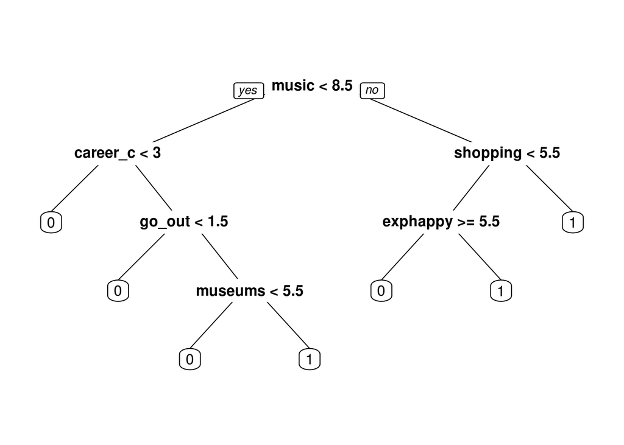

```r
library(rpart)
treeall1=rpart(deci~.-deci-iid,main)
rpart.plot::prp(treeall1)
```

Результаты на обучающей выборке

```r
library(caret)
rpartPred <- predict(treeall1, main, type = "class")
confusionMatrix(rpartPred,main$deci)
```

```
## Confusion Matrix and Statistics
##
##           Reference
## Prediction  0  1
##          0 50  7
##          1 12 34
##
##                Accuracy : 0.8155
##                  95% CI : (0.727, 0.8851)
##     No Information Rate : 0.6019
##     P-Value [Acc > NIR] : 2.783e-06
##
##                   Kappa : 0.6229
##  Mcnemar's Test P-Value : 0.3588
##
##             Sensitivity : 0.8065
##             Specificity : 0.8293
##          Pos Pred Value : 0.8772
##          Neg Pred Value : 0.7391
##              Prevalence : 0.6019
##          Detection Rate : 0.4854
##    Detection Prevalence : 0.5534
##       Balanced Accuracy : 0.8179
##
##        'Positive' Class : 0
##
```

Результаты на тестовой выборке

```r
rpartPred <- predict(treeall1, test, type = "class")
rpartPred = as.data.frame(rpartPred)
rownames(rpartPred) = test$iid
rpartPred$iid = test$iid
```

### SVM linear

```r
library("e1071")
svm_model <- svm(deci~.-deci-iid, data=main, kernel="linear")
summary(svm_model)
```

```
##
## Call:
## svm(formula = deci ~ . - deci - iid, data = main, kernel = "linear")
##
##
## Parameters:
##    SVM-Type:  C-classification
##  SVM-Kernel:  linear
##        cost:  1
##       gamma:  0.03125
##
## Number of Support Vectors:  61
##
##  ( 31 30 )
##
##
## Number of Classes:  2
##
## Levels:
##  0 1
```

Результаты на обучающей выборке

```r
svm.Pred<-predict(svm_model, main, probability=FALSE)
confusionMatrix(svm.Pred,main$deci)
```

```
## Confusion Matrix and Statistics
##
##           Reference
## Prediction  0  1
##          0 56 10
##          1  6 31
##
##                Accuracy : 0.8447
##                  95% CI : (0.76, 0.9085)
##     No Information Rate : 0.6019
##     P-Value [Acc > NIR] : 8.075e-08
##
##                   Kappa : 0.6704
##  Mcnemar's Test P-Value : 0.4533
##
##             Sensitivity : 0.9032
##             Specificity : 0.7561
##          Pos Pred Value : 0.8485
##          Neg Pred Value : 0.8378
##              Prevalence : 0.6019
##          Detection Rate : 0.5437
##    Detection Prevalence : 0.6408
##       Balanced Accuracy : 0.8297
##
##        'Positive' Class : 0
##
```

Результаты на тестовой выборке

```r
svm.Pred<-predict(svm_model, test, probability=FALSE)
svm.Pred = as.data.frame(svm.Pred)
rownames(svm.Pred) = test$iid
svm.Pred$iid = test$iid
```

### SVM polynomial

```r
library("e1071")
svm_modelpoly <- svm(deci~.-deci-iid, data=main, kernel="polynomial")
summary(svm_modelpoly)
```

```
##
## Call:
## svm(formula = deci ~ . - deci - iid, data = main, kernel = "polynomial")
##
##
## Parameters:
##    SVM-Type:  C-classification
##  SVM-Kernel:  polynomial
##        cost:  1
##      degree:  3
##       gamma:  0.03125
##      coef.0:  0
##
## Number of Support Vectors:  99
##
##  ( 58 41 )
##
##
## Number of Classes:  2
##
## Levels:
##  0 1
```

Результаты на обучающей выборке

```r
svmpoly.Pred<-predict(svm_modelpoly, main, probability=FALSE)
confusionMatrix(svmpoly.Pred,main$deci)
```

```
## Confusion Matrix and Statistics
##
##           Reference
## Prediction  0  1
##          0 62 14
##          1  0 27
##
##                Accuracy : 0.8641
##                  95% CI : (0.7825, 0.9237)
##     No Information Rate : 0.6019
##     P-Value [Acc > NIR] : 5.378e-09
##
##                   Kappa : 0.699
##  Mcnemar's Test P-Value : 0.000512
##
##             Sensitivity : 1.0000
##             Specificity : 0.6585
##          Pos Pred Value : 0.8158
##          Neg Pred Value : 1.0000
##              Prevalence : 0.6019
##          Detection Rate : 0.6019
##    Detection Prevalence : 0.7379
##       Balanced Accuracy : 0.8293
##
##        'Positive' Class : 0
##
```

Результаты на тестовой выборке

```r
svmpoly.Pred<-predict(svm_modelpoly, test, probability=FALSE)
svmpoly.Pred = as.data.frame(svmpoly.Pred)
rownames(svmpoly.Pred) = test$iid
svmpoly.Pred$iid = test$iid
```

### Случайный лес

```r
library(randomForest)
rfModel <-randomForest(deci~.-deci-iid, data=main)
summary(rfModel)
```

```
##                 Length Class  Mode
## call               3   -none- call
## type               1   -none- character
## predicted        103   factor numeric
## err.rate        1500   -none- numeric
## confusion          6   -none- numeric
## votes            206   matrix numeric
## oob.times        103   -none- numeric
## classes            2   -none- character
## importance        32   -none- numeric
## importanceSD       0   -none- NULL
## localImportance    0   -none- NULL
## proximity          0   -none- NULL
## ntree              1   -none- numeric
## mtry               1   -none- numeric
## forest            14   -none- list
## y                103   factor numeric
## test               0   -none- NULL
## inbag              0   -none- NULL
## terms              3   terms  call
```

Результаты на обучающей выборке

```r
rfPred<-predict(rfModel, main, probability=FALSE)
confusionMatrix(rfPred,main$deci)
```

```
## Confusion Matrix and Statistics
##
##           Reference
## Prediction  0  1
##          0 62  0
##          1  0 41
##
##                Accuracy : 1
##                  95% CI : (0.9648, 1)
##     No Information Rate : 0.6019
##     P-Value [Acc > NIR] : < 2.2e-16
##
##                   Kappa : 1
##  Mcnemar's Test P-Value : NA
##
##             Sensitivity : 1.0000
##             Specificity : 1.0000
##          Pos Pred Value : 1.0000
##          Neg Pred Value : 1.0000
##              Prevalence : 0.6019
##          Detection Rate : 0.6019
##    Detection Prevalence : 0.6019
##       Balanced Accuracy : 1.0000
##
##        'Positive' Class : 0
##
```

Результаты на тестовой выборке

```r
rfPred<-predict(rfModel, test, probability=FALSE)
rfPred = as.data.frame(rfPred)
rownames(rfPred) = test$iid
rfPred$iid = test$iid
summary(rfPred)
```

```
##  rfPred       iid
##  0:365   Min.   :  4.0
##  1:169   1st Qu.:145.2
##          Median :278.5
##          Mean   :279.3
##          3rd Qu.:417.8
##          Max.   :552.0
```

```r
predictall = inner_join(rpartPred,svm.Pred, by = "iid")
predictall = inner_join(predictall,svmpoly.Pred, by = "iid")
predictall = inner_join(predictall,rfPred, by = "iid")
predictall = predictall[c(2,1,3,4,5)]
```

```r
predictall$rpartPred = as.numeric(predictall$rpartPred)
predictall$svm.Pred = as.numeric(predictall$svm.Pred)
predictall$svmpoly.Pred = as.numeric(predictall$svmpoly.Pred)
predictall$rfPred = as.numeric(predictall$rfPred)
```

```r
pred = c("rpartPred", "svm.Pred", "svmpoly.Pred", "rfPred")
predictall1 = mutate(predictall, mean = rowMeans(predictall[pred]))
#predictall2 = head (arrange(predictall1, -mean), 25)
predictall2 = filter(predictall1, mean==2)
```

```r
done = filter(SD22NA, iid %in% predictall2$iid)
```

iid - уникальный номер age - возраст gender - пол career_c - закодированная карьерная область 1= Lawyer 2= Academic/Research 3= Psychologist 4= Doctor/Medicine 5=Engineer 6= Creative Arts/Entertainment 7= Banking/Consulting/Finance/Marketing/Business/CEO/Entrepreneur/Admin 8= Real Estate 9= International/Humanitarian Affairs 10= Undecided 11=Social Work 12=Speech Pathology 13=Politics 14=Pro sports/Athletics 15=Other 16=Journalism 17=Architecture

Интересы: sports: Playing sports/ athletics tvsports: Watching sports exercise: Body building/exercising dining: Dining out museums: Museums/galleries art: Art hiking: Hiking/camping gaming: Gaming clubbing: Dancing/clubbing reading: Reading tv: Watching TV theater: Theater movies: Movies concerts: Going to concerts music: Music shopping: Shopping yoga: Yoga/meditation

Личные характеристики: attr3_1 Attractive sinc3_1 Sincere intel3_1 Intelligent fun3_1 Fun amb3_1 Ambitious

field_cd закодированный field of study 1= Law 2= Math 3= Social Science, Psychologist 4= Medical Science, Pharmaceuticals, and Bio Tech 5= Engineering 6= English/Creative Writing/ Journalism 7= History/Religion/Philosophy 8= Business/Econ/Finance 9= Education, Academia 10= Biological Sciences/Chemistry/Physics 11= Social Work 12= Undergrad/undecided 13=Political Science/International Affairs 14=Film 15=Fine Arts/Arts Administration 16=Languages 17=Architecture 18=Other

race Black/African American=1 European/Caucasian-American=2 Latino/Hispanic American=3 Asian/Pacific Islander/Asian-American=4 Native American=5 Other=6

imprace: How important is it to you (on a scale of 1-10) that a person you date be of the same racial/ethnic background? imprelig: How important is it to you (on a scale of 1-10) that a person you date be of the same religious background? zipcode: What was the zip code of the area where you grew up?

goal: What is your primary goal in participating in this event? Seemed like a fun night out=1 To meet new people=2 To get a date=3 Looking for a serious relationship=4 To say I did it=5 Other=6

date: In general, how frequently do you go on dates? Several times a week=1 Twice a week=2 Once a week=3 Twice a month=4 Once a month=5 Several times a year=6 Almost never=7

go out: How often do you go out (not necessarily on dates)? Several times a week=1 Twice a week=2 Once a week=3 Twice a month=4 Once a month=5 Several times a year=6 Almost never=7

career_c: career coded 1= Lawyer 2= Academic/Research 3= Psychologist 4= Doctor/Medicine 5=Engineer 6= Creative Arts/Entertainment 7= Banking/Consulting/Finance/Marketing/Business/CEO/Entrepreneur/Admin 8= Real Estate 9= International/Humanitarian Affairs 10= Undecided 11=Social Work 12=Speech Pathology 13=Politics 14=Pro sports/Athletics 15=Other 16=Journalism 17=Architecture

exphappy: Overall, on a scale of 1-10, how happy do you expect to be with the people you meet during the speed-dating event?